# Drought and Flood: NOLA CAREER Project

Connor Whalen

2025-02-18

# Introduction

This file contains all code pertaining to the CAREER project in NOLA’s drought and flood analysis.

# Setup

#### Load full datasets (parasites collected and NOAA SPI precipitation data) and prep data for analysis

# Drought / Flood analysis and data prepping

### Controls

Find the average date of a hurricane, so that we can identify when the average hurricane starts and stops and how long it lasts – this will be used to assign a period of time to our hurricane controls. [This code was used to identify these information, but no longer needs to be run for the analysis to work]. Then, pick out the years in which there was no hurricane, so that we can identify which years to assign as control in our hurricane analysis. [These are dates of average drought as it pertains to the initial analysis plan (the one that mirrors the hurricane analysis plan) – not currently in use.]

Add actual drought/flood timeline parameters for 6 month (6 month meaning a buffer period of 6 months before a drought/flood [denoted as pre] and 6 months after a drought/flood [denoted post]). These dates for drought/flood occurrence are taken from the [NOAA flooding website](https://www.weather.gov/safety/flood-states-la#) and the CAREER proposal from the Wood Lab, and represent all drought/flood events that occurred near the Pearl River in Louisiana across the sampling period. [This is the old/original analysis the same as hurricanes, but we are going to use the alternate analysis method of the matched SPI data instead – not currently in use.]

Visualization and checking of data frame.

```r
head(drought_flood_df)
```

```
##   x x1            fish_psite_combo catalog_number year_collected
## 1 1  1 Carpiodes velifer_CEST.ARCH         178358           1996
## 2 2  2 Carpiodes velifer_CEST.ARCH          31000           1963
## 3 3  3 Carpiodes velifer_CEST.ARCH          31000           1963
## 4 4  4 Carpiodes velifer_CEST.ARCH          31000           1963
## 5 5  5 Carpiodes velifer_CEST.ARCH          31000           1963
## 6 6  6 Carpiodes velifer_CEST.ARCH          31000           1963
##   month_collected day_collected individual_fish_id dissector_and_examiner
## 1               4             6          178358_02         JT DMDM KL GMC
## 2              12            12           31000_02             ij djb cjw
## 3              12            12           31000_06               DJB DMDM
## 4              12            12           31000_04                 djb kl
## 5              12            12           31000_03               djb dmdm
## 6              12            12           31000_05                jt dmdm
##   dissection_date sex total_length_mm standard_length_mm weight_mg      ci
```

[output cut: 55 more lines]

# Plots

Create color palette and assign faceting labels.

# Models

## Drought/Flood count (abundance)

```r
summary(drought_flood_count <- glmmTMB(psite_abundance ~ event*timing*psite_type + (total_length_mm|fish_sp_x/parasite_taxonomic_group) + (1|ci/catalog_number) + (1|year_collected/season) + (1|fish_sp_y/psite_spp_y),
                          data = drought_flood_df, family = truncated_nbinom1, ziformula = ~ 1))
```

```
##  Family: truncated_nbinom1  ( log )
## Formula:
## psite_abundance ~ event * timing * psite_type + (total_length_mm |
##     fish_sp_x/parasite_taxonomic_group) + (1 | ci/catalog_number) +
##     (1 | year_collected/season) + (1 | fish_sp_y/psite_spp_y)
## Zero inflation:                   ~1
## Data: drought_flood_df
##
##      AIC      BIC   logLik deviance df.resid
##       NA       NA       NA       NA     9192
##
## Random effects:
##
## Conditional model:
##  Groups                             Name            Variance  Std.Dev. Corr
##  parasite_taxonomic_group:fish_sp_x (Intercept)     8.330e-02 0.28861
##                                     total_length_mm 5.698e-04 0.02387  -0.91
##  fish_sp_x                          (Intercept)     4.501e-02 0.21215
##                                     total_length_mm 1.897e-04 0.01377  -0.87
##  catalog_number:ci                  (Intercept)     4.606e-01 0.67867
##  ci                                 (Intercept)     2.267e-03 0.04762
##  season:year_collected              (Intercept)     4.451e-03 0.06672
##  year_collected                     (Intercept)     2.351e-02 0.15332
##  psite_spp_y:fish_sp_y              (Intercept)     3.162e+01 5.62292
##  fish_sp_y                          (Intercept)     5.659e-02 0.23788
## Number of obs: 9264, groups:
## parasite_taxonomic_group:fish_sp_x, 39; fish_sp_x, 7; catalog_number:ci, 129; ci, 2; season:year_collected, 51; year_collected, 29; psite_spp_y:fish_sp_y, 148; fish_sp_y, 7
##
## Dispersion parameter for truncated_nbinom1 family (): 17.3
##
## Conditional model:
##                                                          Estimate Std. Error
## (Intercept)                                              -4.62834        NaN
## eventdrought                                             -1.32531        NaN
## eventflood                                               -0.59821        NaN
## timingpost                                               -0.65967        NaN
## psite_typecestode                                        -1.25429        NaN
## psite_typeciliate                                         0.00000        NaN
## psite_typecopepod                                        -0.35499        NaN
## psite_typeleech                                          -0.22660        NaN
```

[output cut: 102 more lines]

```
## eventflood:timingpost:psite_typeleech                        NaN      NaN
## eventdrought:timingpost:psite_typemonogenean                 NaN      NaN
## eventflood:timingpost:psite_typemonogenean                   NaN      NaN
## eventdrought:timingpost:psite_typenematode                   NaN      NaN
## eventflood:timingpost:psite_typenematode                     NaN      NaN
## eventdrought:timingpost:psite_typenematomorph                NaN      NaN
## eventflood:timingpost:psite_typenematomorph                  NaN      NaN
## eventdrought:timingpost:psite_typetrematode                  NaN      NaN
## eventflood:timingpost:psite_typetrematode                    NaN      NaN
## eventdrought:timingpost:psite_typetrematode_metacercaria     NaN      NaN
## eventflood:timingpost:psite_typetrematode_metacercaria       NaN      NaN
##
## Zero-inflation model:
##             Estimate Std. Error z value Pr(>|z|)
## (Intercept)    2.738        NaN     NaN      NaN
```

Create diagnostics.

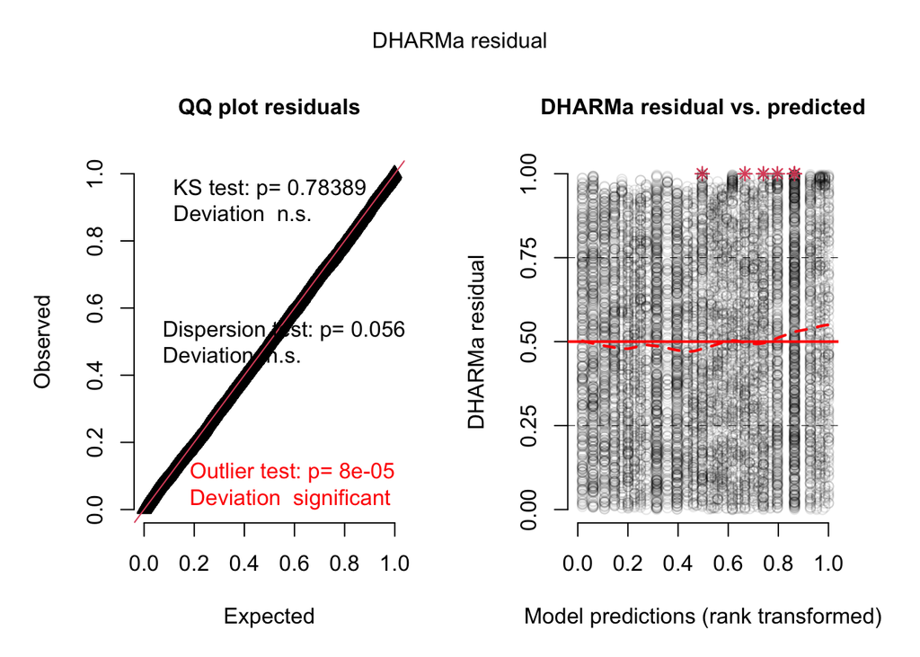

```r
# diagnostics
#Evaluate residuals
s = simulateResiduals(fittedModel = drought_flood_count, n = 250)
plot(s)
```

```r
# other possible diagnostics
#df <- ggpredict(model, terms = "column[n=100]")
#plot(df)
#plot(df, show_data=TRUE)
```

## Drought/Flood prevalence (presence/absence for myxozoans) [not currently working]